# Chapter 8: Forecasting Use of Soybeans in the WASDE Balance Sheet

# Introduction

In the WASDE balance sheet for soybeans there are three use categories. Two account for domestic consumption - Crush, and Feed, Seed, and Residual - while exports make up the third category. The main distinction between cereal grains, like corn, and oilseeds, like soybeans, is that cereal grains are generally ground whole for whatever the end use turns out to be. Most oilseeds, on the other hand, are crushed to extract oil and meal before their ultimate use. Soybean oil is food-grade and can be found on the shelves of any American grocery store. Soybean meal is protein rich and used as an ingredient in livestock feed rations.

In the next sections we will examine historical use patterns of soybeans in the three categories expressed nominally, and as a percent of the concurrent year’s total supply, similar to the orginization of chapter 7.

# Examining Historical Trends

Since this book has taken a closer look at corn production than soybean production, we will ground our discussion of use by first noting the pattern of annual supply of soybeans in recent history.

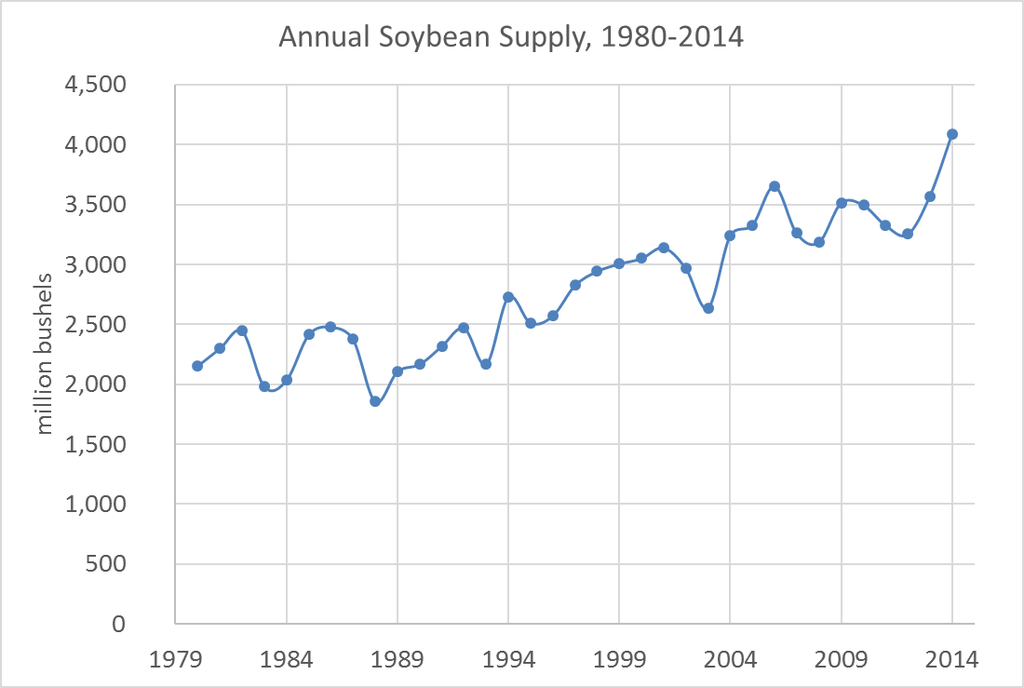

Figure 1: Annual Soybean Supply, 1980-2014

Source: [USDA ERS Oil Crops Yearbook](http://www.ers.usda.gov/data-products/oil-crops-yearbook.aspx)

Since soybeans are not consumed whole as food by humans or feed for animals in the U.S., nearly all the soybean supply is crushed domestically or exported.

# Soybean Crush

Figure 2 displays the annual crush of soybeans from 1980-2014. A pronounced upward trend, similar to the trend in soybean supply is observed.

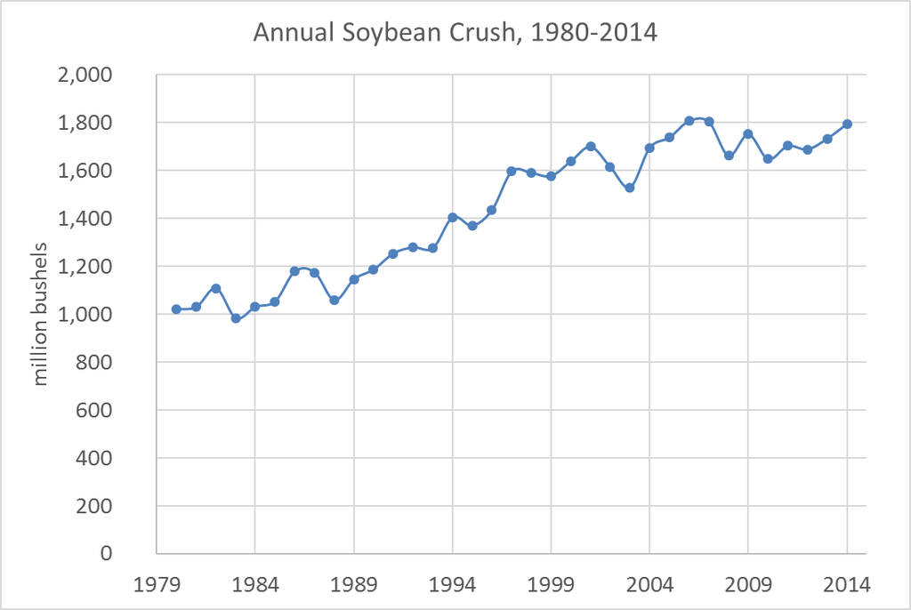

Figure 2: Annual Soybean Crush, 1980-2014

Source: [USDA ERS Oil Crops Yearbook](http://www.ers.usda.gov/data-products/oil-crops-yearbook.aspx)

When examining corn use, we saw that the proportion of supply shifted dramatically from other use categories to Food, Seed, and Industrial use due to the increase in ethanol production since 2005. In figure 3, we show soybean crush as a percent of the concurrent year’s total supply. While the bushels of soybeans devoted to the crush is steadily increasing, figure 3 shows that the crush is increasing roughly proportionally. There does not seem to be a shift into or out of the crush category.

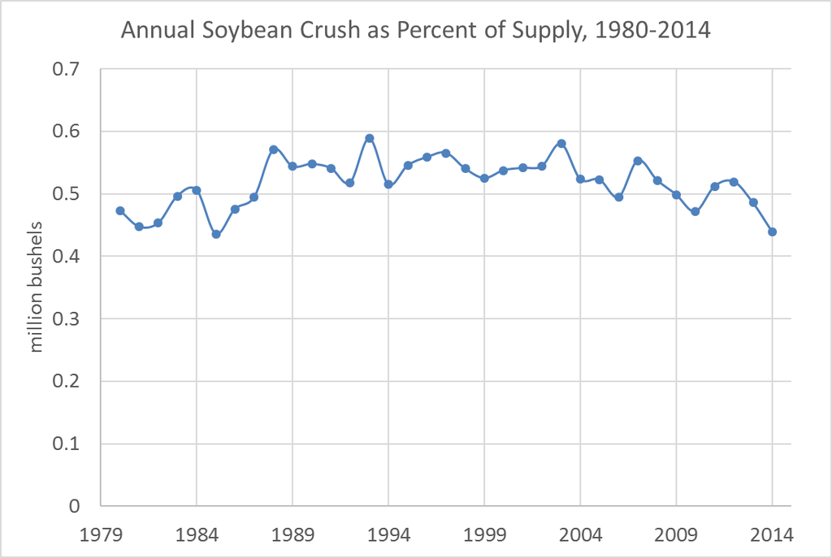

Figure 3: Annual Soybean Crush as a Percent of Supply, 1980-2014

Source: [USDA ERS Oil Crops Yearbook](http://www.ers.usda.gov/data-products/oil-crops-yearbook.aspx)

# Soybean Exports

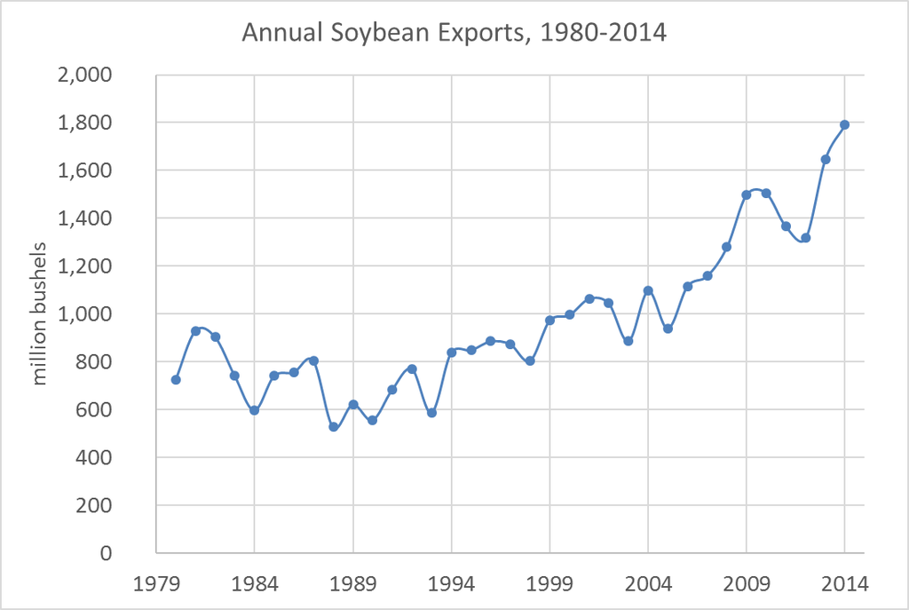

Figure 4: Annual Soybean Exports, 1980-2014

Source: [USDA ERS Oil Crops Yearbook](http://www.ers.usda.gov/data-products/oil-crops-yearbook.aspx)

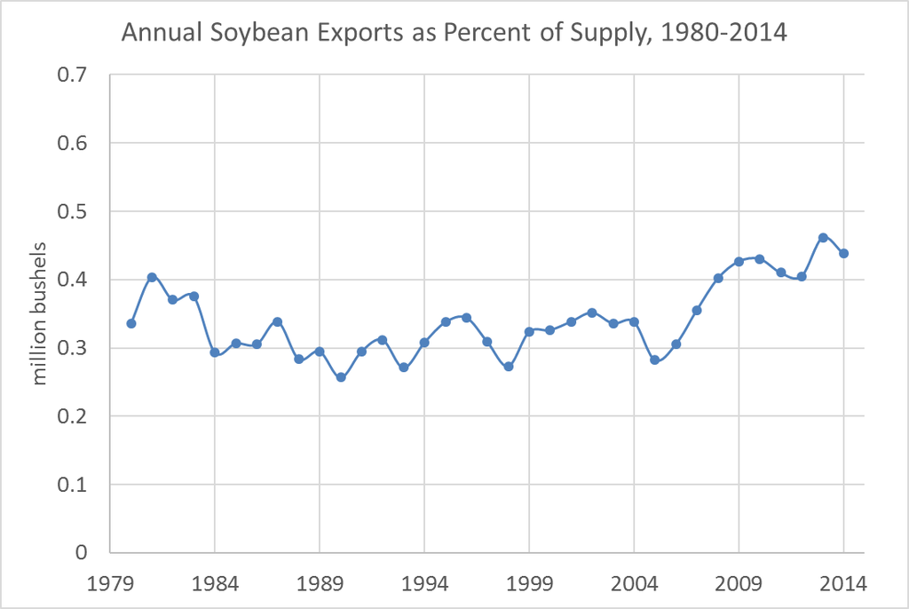

Source: [USDA ERS Oil Crops Yearbook](http://www.ers.usda.gov/data-products/oil-crops-yearbook.aspx)